# STAT 579-Fall2014-Homework 1

Somenath Bera

Tuesday, September 09, 2014

#### check for github

In this homework the task is to investigate the diamond data set. We begin by setting our working directory.

```r
setwd("C:/Users/Somenath Bera/Dropbox/Courses/STAT 579/HW1")
```

This data set is a part of ggplot2 package, so we will install the package.

Next we load the ggplot2 library

```r
library(ggplot2)
```

Call the data set

```r
data(diamonds)
```

Next we check if the data is loaded properly and learn its basics

```r
help(diamonds)
```

```
## starting httpd help server ... done
```

```r
head(diamonds)
```

```
##   carat       cut color clarity depth table price    x    y    z
## 1  0.23     Ideal     E     SI2  61.5    55   326 3.95 3.98 2.43
## 2  0.21   Premium     E     SI1  59.8    61   326 3.89 3.84 2.31
## 3  0.23      Good     E     VS1  56.9    65   327 4.05 4.07 2.31
## 4  0.29   Premium     I     VS2  62.4    58   334 4.20 4.23 2.63
## 5  0.31      Good     J     SI2  63.3    58   335 4.34 4.35 2.75
## 6  0.24 Very Good     J    VVS2  62.8    57   336 3.94 3.96 2.48
```

```r
str(diamonds)
```

```
## 'data.frame':    53940 obs. of  10 variables:
##  $ carat  : num  0.23 0.21 0.23 0.29 0.31 0.24 0.24 0.26 0.22 0.23 ...
##  $ cut    : Ord.factor w/ 5 levels "Fair"<"Good"<..: 5 4 2 4 2 3 3 3 1 3 ...
##  $ color  : Ord.factor w/ 7 levels "D"<"E"<"F"<"G"<..: 2 2 2 6 7 7 6 5 2 5 ...
##  $ clarity: Ord.factor w/ 8 levels "I1"<"SI2"<"SI1"<..: 2 3 5 4 2 6 7 3 4 5 ...
##  $ depth  : num  61.5 59.8 56.9 62.4 63.3 62.8 62.3 61.9 65.1 59.4 ...
##  $ table  : num  55 61 65 58 58 57 57 55 61 61 ...
##  $ price  : int  326 326 327 334 335 336 336 337 337 338 ...
##  $ x      : num  3.95 3.89 4.05 4.2 4.34 3.94 3.95 4.07 3.87 4 ...
##  $ y      : num  3.98 3.84 4.07 4.23 4.35 3.96 3.98 4.11 3.78 4.05 ...
##  $ z      : num  2.43 2.31 2.31 2.63 2.75 2.48 2.47 2.53 2.49 2.39 ...
```

```r
dim(diamonds)
```

```
## [1] 53940    10
```

Aim

Our aim is to find any unusual pattern in the dataset. We employ various techniques to visulaize the data to find any patterns. Our intuition tells us that higher carat, better cut and color, higher clarity, and bigger diamonds should have higher prices. Let us examine what combinations give us highest prices.

Methods

Summary Statistics of the data set will reveal any missing values and other information.

```r
summary(diamonds)
```

```
##      carat              cut        color        clarity
##  Min.   :0.200   Fair     : 1610   D: 6775   SI1    :13065
##  1st Qu.:0.400   Good     : 4906   E: 9797   VS2    :12258
##  Median :0.700   Very Good:12082   F: 9542   SI2    : 9194
##  Mean   :0.798   Premium  :13791   G:11292   VS1    : 8171
##  3rd Qu.:1.040   Ideal    :21551   H: 8304   VVS2   : 5066
##  Max.   :5.010                     I: 5422   VVS1   : 3655
##                                    J: 2808   (Other): 2531
##      depth          table          price             x
##  Min.   :43.0   Min.   :43.0   Min.   :  326   Min.   : 0.00
##  1st Qu.:61.0   1st Qu.:56.0   1st Qu.:  950   1st Qu.: 4.71
##  Median :61.8   Median :57.0   Median : 2401   Median : 5.70
##  Mean   :61.8   Mean   :57.5   Mean   : 3933   Mean   : 5.73
##  3rd Qu.:62.5   3rd Qu.:59.0   3rd Qu.: 5324   3rd Qu.: 6.54
##  Max.   :79.0   Max.   :95.0   Max.   :18823   Max.   :10.74
##
##        y               z
##  Min.   : 0.00   Min.   : 0.00
##  1st Qu.: 4.72   1st Qu.: 2.91
##  Median : 5.71   Median : 3.53
##  Mean   : 5.73   Mean   : 3.54
##  3rd Qu.: 6.54   3rd Qu.: 4.04
##  Max.   :58.90   Max.   :31.80
##
```

Graphical Overviews

1. Scatterplot of Carat vs Price

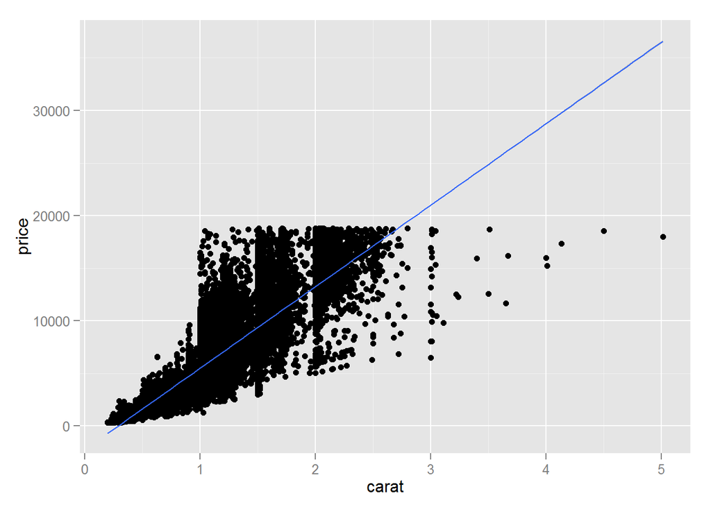

```r
qplot(carat, price, geom="point", data=diamonds) + geom_smooth(method="lm")
```

Investigating for other factors that influence price; scatterplots of tips with combinations.

2. Scatterplot of carat vs price by cut

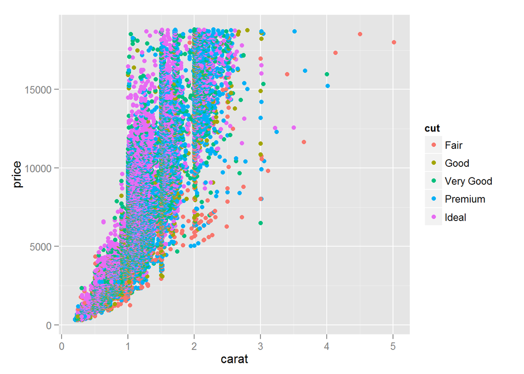

```r
qplot(carat, price, geom="point", data=diamonds, colour=cut)
```

Generally, ideal cuts gives highest prices but not every highest price of each carat is Ideal cut.

3. Scatterplot of carat vs price by clarity

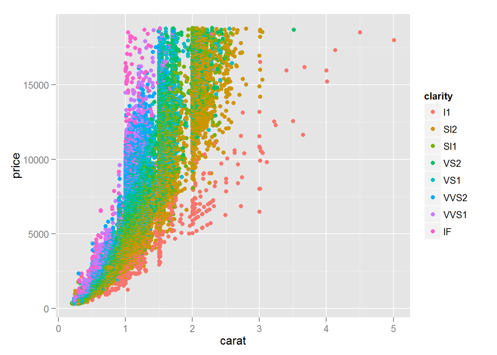

```r
qplot(carat, price, geom="point", data=diamonds, colour=clarity)
```

4. Scatterplot of carat vs price by color

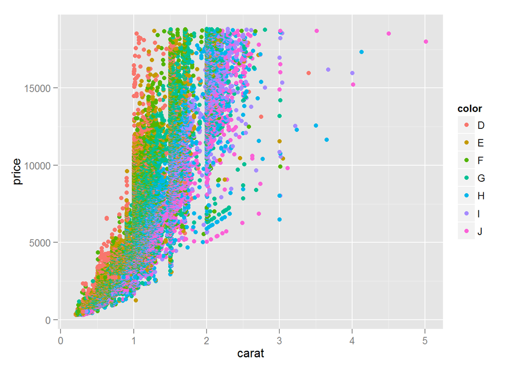

```r
qplot(carat, price, geom="point", data=diamonds, colour=color)
```

Color seems to be an important factor till carat size 1.5, later on moderate colors even worst colors has highest price.

Facetting to reveal more patterns:

5. Carat vs price for all cuts

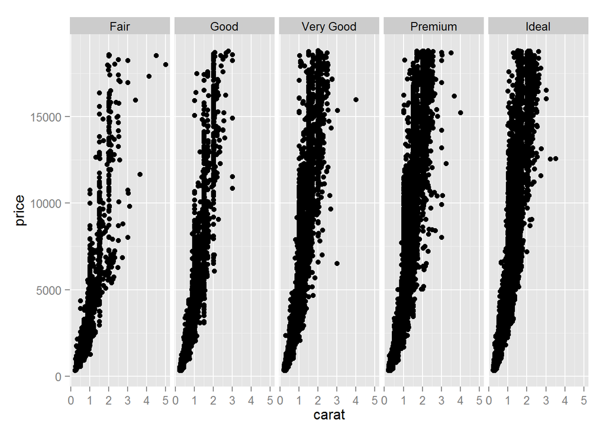

```r
qplot(carat, price, geom="point", facets=.~cut,  data=diamonds)
```

Higher carat gives higher price, particularly with cuts like very good, premium, and ideal.

6. Carat vs price with clarity-cut

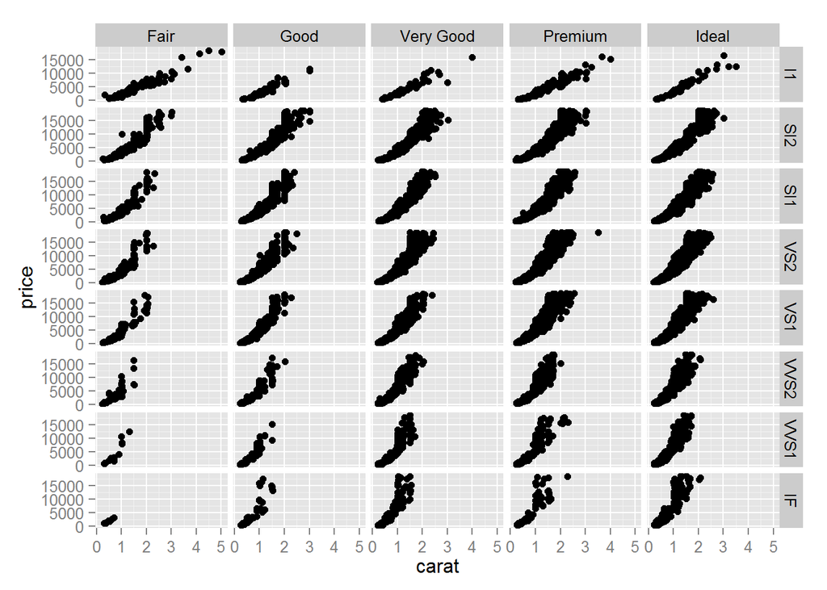

```r
qplot(carat, price, geom="point", facets=clarity~cut,  data=diamonds)
```

All types of cut and poor clarity is a linear plot, implying only carat determines the price. The relationship changes as the clarity gets better.

7. Carat vs Price with color-cut

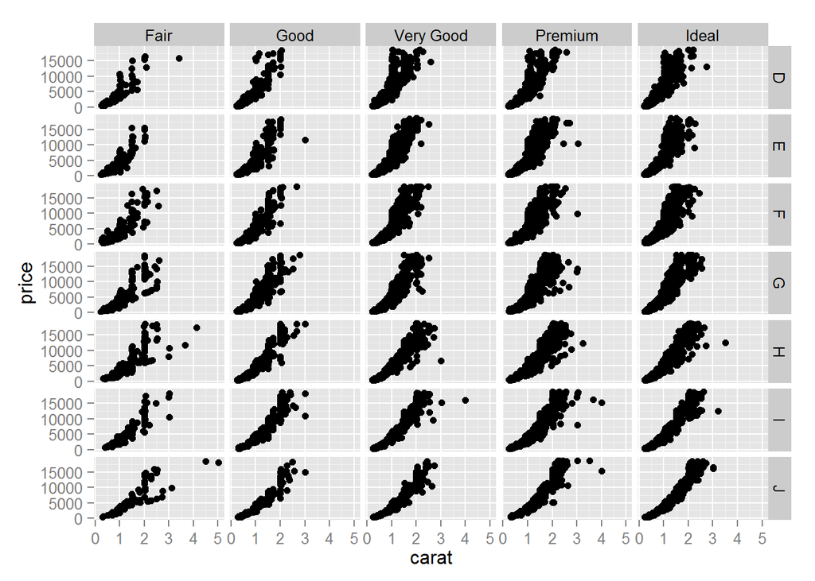

```r
qplot(carat, price, geom="point", facets=color~cut,  data=diamonds)
```

Again, everything else constant, better color gives higher price.

8. Carat vs Price with clarity-color

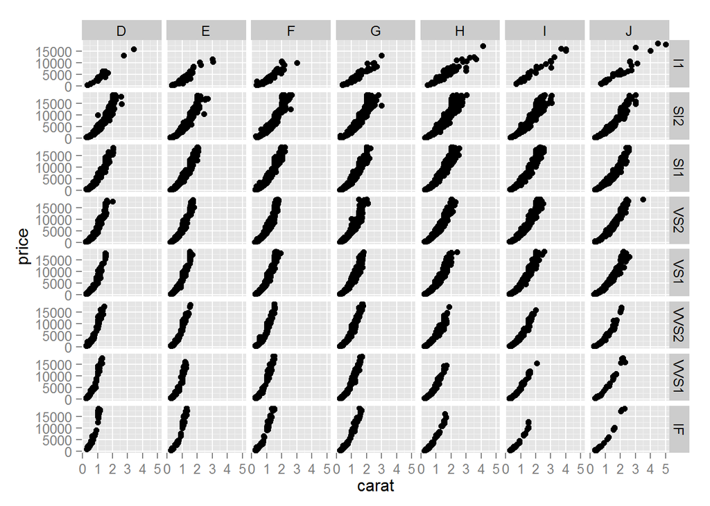

```r
qplot(carat, price, geom="point", facets=clarity~color,  data=diamonds)
```

Given color as clarity increases, price increases; but this relationship is not strong for poorer colors. Also, given clarity, price increases, as color improves.

Creating new variable

Given the fact that carat with combinations of color, clarity, and cut determines the price, it would be nice to plot price per carat against these properties.

```r
diamonds$pricepercarat <- diamonds$price/diamonds$carat
```

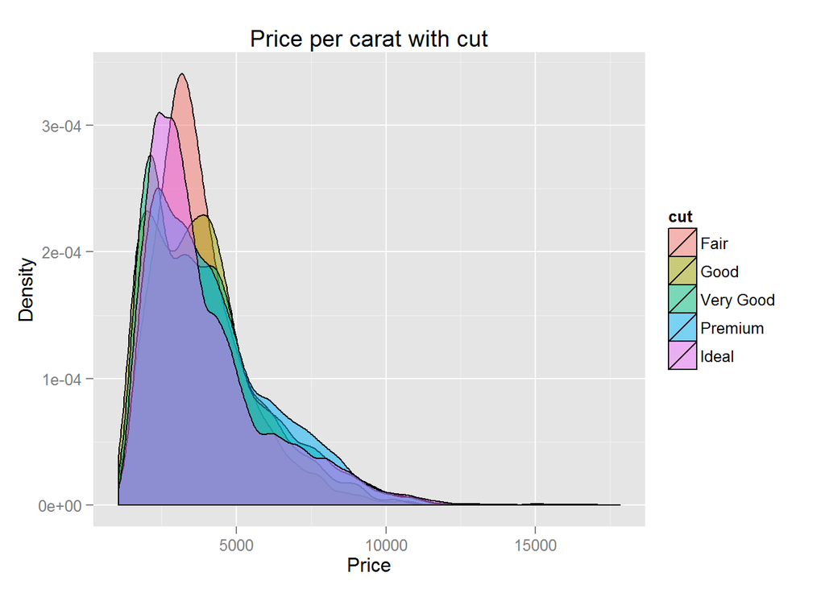

```r
qplot(pricepercarat,data=diamonds,geom="density",fill=cut,alpha=I(.5),
main="Price per carat with cut", xlab="Price", ylab="Density")
```

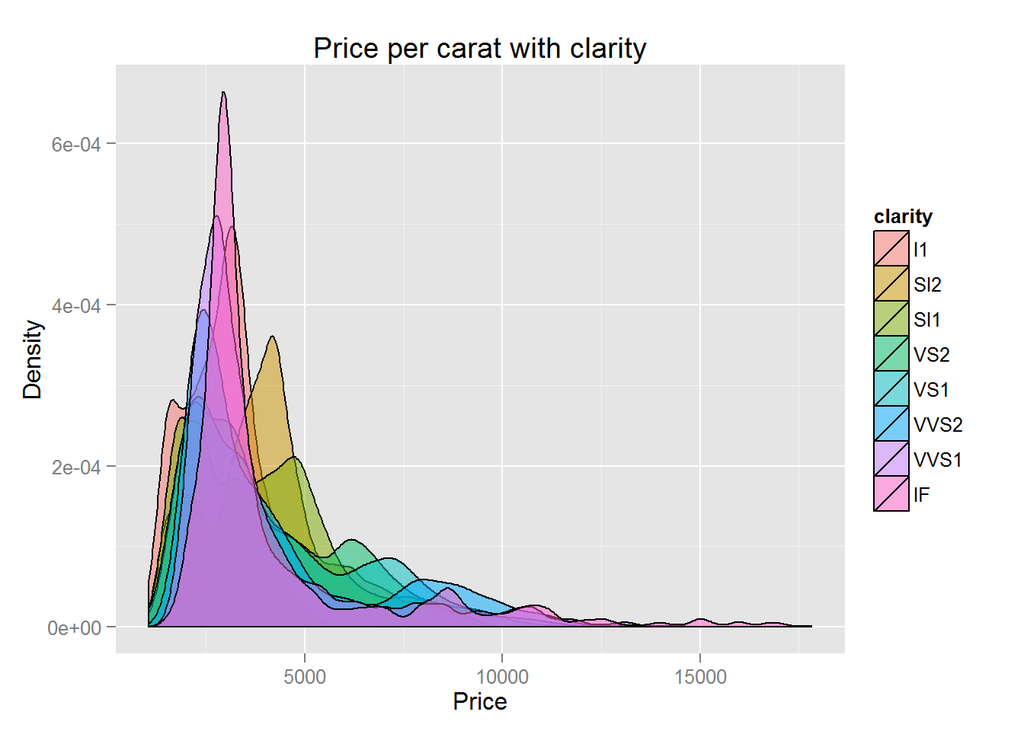

```r
qplot(pricepercarat,data=diamonds,geom="density",fill=clarity,alpha=I(.5),
      main="Price per carat with clarity", xlab="Price", ylab="Density")
```

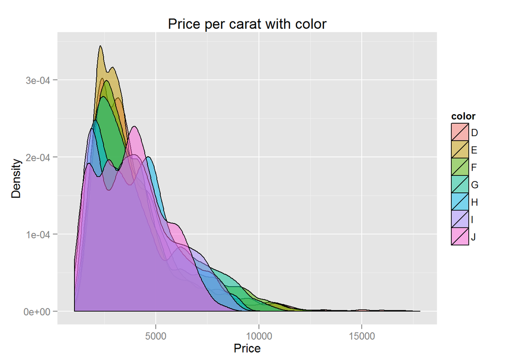

```r
qplot(pricepercarat,data=diamonds,geom="density",fill=color,alpha=I(.5),
      main="Price per carat with color", xlab="Price", ylab="Density")
```

Finally, relationship between volume and weight

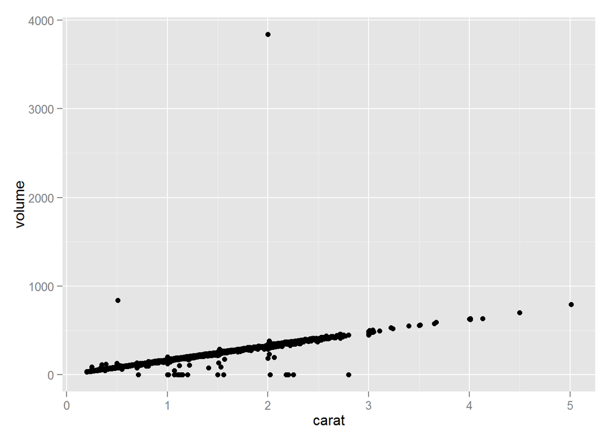

```r
diamonds$volume <- diamonds$x*diamonds$y*diamonds$z
qplot(carat,volume, geom="point", data=diamonds)
```

Reveals a linear relationship between volume and carat.